# C-center models

# 1 Load required packages

```r
library(tidyr)
library(dplyr)
library(stringr)
library(lme4)
library(car)
library(visreg)
library(optimx)
library(lmerTest)
library(emmeans)
library(neldermead)
```

```r
library(ggplot2)
library(optimx)
```

# 2 Introduction

From the c-center hypothesis it follows that onsets are coordinated inphase with the following vowel, meaning that they are initiated roughly around the same time. On the other hand, multiple consonants in an onset are also coordinated antiphase with each other (i.e. sequential initiation). To cope with these competing relations, the leftmost C gets shifted towards the left and the rightmost C gets shifted towards the right (with respect to the following vowel) in complex onsets. In this way, the average onset of the two C’s is still initiated at the same time as the vowel, whereas they are also still coordinated in an antiphase relation with each other. Our hypothesis is that PD patients will show a stronger preference for the inphase relationship, coming at the cost of the antiphase relationship. In our data we’ve included three singular onsets /p/, /m/ and /x/ and four complex onsets: /sp/, /sm/, /sx/ and /spr/. The variable ‘time.lag’ is the time lag between the offset of the leftmost C and the onset of the rightmost C. If our hypothesis is correct the lag between the C’s should be lower for the PD group in comparison with the controls.

## 2.1 Read data

```r
df <- readRDS("../data/modelling_data_CC.rds")
```

## 2.2 Clean data

Remove all the rows that have NA in the dependent variable and drop ‘empty’ levels, convert variables to factors and create trimmed dataset.

```r
df <- df[complete.cases(df$time.lag.norm),]
df <- droplevels(df)

# convert to factors/numeric
df$prompt <- as.factor(df$prompt)
df$condition <- as.factor(df$condition)

# remove all the recordings without a speech rate measure:
df <- df %>% drop_na(duration.tt)

# remove participants with only a few datapoints
#remove <- c("PD19", "CTRL19")
#df.trim <- df[! df$subj %in% remove, ]
#df.trim <- droplevels(df.trim)


# create df without sx
#df.trim <- df.trim[! df.trim$cluster == "sx", ]
#df.trim <- droplevels(df.trim)
#levels(df.trim$cluster)

# create df without spr
df.nospr <- df[! df$cluster == "spr", ]
df.nospr <- droplevels(df.nospr)
levels(df.nospr$cluster)
```

```
## [1] "sm" "sp" "sx"
```

```r
# Change order of levels in cluster
df$cluster <- factor(df$cluster, levels = c("sp", "sm", "sx", "spr"))
```

# 3 LME models for CC lag analysis (coarticulation)

If indeed patients would show a stronger preference for inphase coordination, this would mean that they would produce the C gestures in the syllable’s onset closer together in time. For this, we look at the lag between the gestural offset of the leftmost C and the gestural onset of the righmost C in complex clusters.

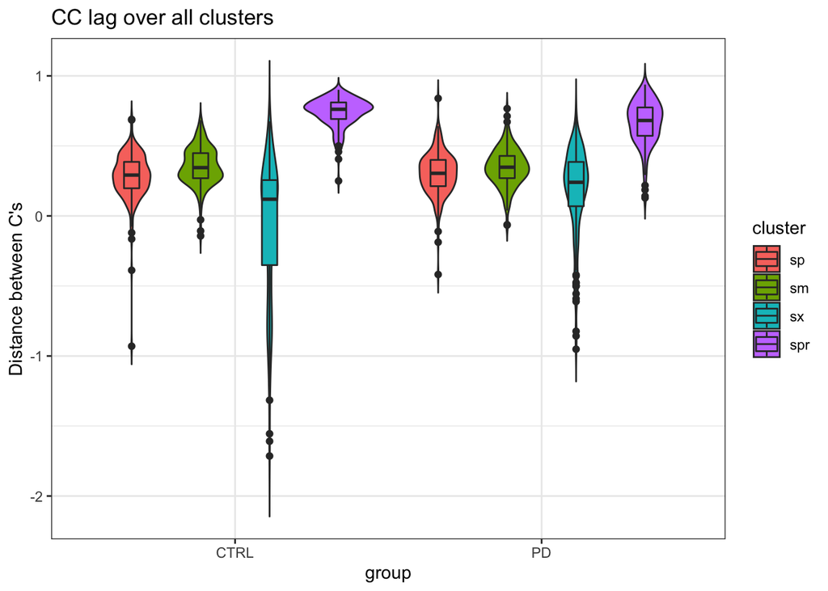

```r
#CC
dodge <- position_dodge(width = 0.9)
ggplot(df, aes(x=group, y=time.lag.norm, fill=cluster)) + theme_bw() + geom_violin(trim=FALSE) + labs(title = "CC lag over all clusters", y = "Distance between C's") + geom_boxplot(width=.2, position = dodge)
```

## 3.1 Hypothesis testing

Fitting first model:

```r
summary(m <- lmer(time.lag.norm ~ (1|subj), data=df.nospr))
```

```
## Linear mixed model fit by REML. t-tests use Satterthwaite's method [
## lmerModLmerTest]
## Formula: time.lag.norm ~ (1 | subj)
##    Data: df.nospr
##
## REML criterion at convergence: 404.8
##
## Scaled residuals:
##     Min      1Q  Median      3Q     Max
## -6.4868 -0.2486  0.1085  0.4922  2.6595
##
## Random effects:
##  Groups   Name        Variance Std.Dev.
##  subj     (Intercept) 0.01160  0.1077
##  Residual             0.07716  0.2778
## Number of obs: 1185, groups:  subj, 47
##
## Fixed effects:
##             Estimate Std. Error       df t value Pr(>|t|)
## (Intercept)  0.24239    0.01783 46.44939    13.6   <2e-16 ***
## ---
## Signif. codes:  0 '***' 0.001 '**' 0.01 '*' 0.05 '.' 0.1 ' ' 1
```

Adding cluster as fixed effect:

```r
summary(m1 <- lmer(time.lag.norm ~ cluster + (1|subj), data=df.nospr))
```

```
## Linear mixed model fit by REML. t-tests use Satterthwaite's method [
## lmerModLmerTest]
## Formula: time.lag.norm ~ cluster + (1 | subj)
##    Data: df.nospr
##
## REML criterion at convergence: 136.8
##
## Scaled residuals:
##     Min      1Q  Median      3Q     Max
## -6.5164 -0.4147  0.0160  0.5280  2.5827
##
## Random effects:
##  Groups   Name        Variance Std.Dev.
##  subj     (Intercept) 0.01172  0.1082
##  Residual             0.06050  0.2460
## Number of obs: 1185, groups:  subj, 47
##
## Fixed effects:
##               Estimate Std. Error         df t value Pr(>|t|)
## (Intercept)    0.35372    0.02010   80.46224  17.599  < 2e-16 ***
## clustersp     -0.06298    0.01702 1141.44092  -3.701 0.000225 ***
## clustersx     -0.31093    0.01823 1150.15665 -17.057  < 2e-16 ***
## ---
## Signif. codes:  0 '***' 0.001 '**' 0.01 '*' 0.05 '.' 0.1 ' ' 1
##
## Correlation of Fixed Effects:
##           (Intr) clstrsp
## clustersp -0.440
## clustersx -0.408  0.481
```

```r
anova(m,m1)
```

```
## refitting model(s) with ML (instead of REML)
```

|  | npar | AIC | BIC | logLik | deviance | Chisq | Df | Pr(>Chisq) |
| --- | --- | --- | --- | --- | --- | --- | --- | --- |
| m | 3 | 404.5629 | 419.7954 | -199.28147 | 398.5629 | NA | NA | NA |
| m1 | 5 | 127.7832 | 153.1707 | -58.89161 | 117.7832 | 280.7797 | 2 | 1.070182e-61 |

Sign. improvement.

Adding group as fixed effect:

```r
summary(m2 <- lmer(time.lag.norm ~ cluster + group + (1|subj), data=df.nospr))
```

```
## Linear mixed model fit by REML. t-tests use Satterthwaite's method [
## lmerModLmerTest]
## Formula: time.lag.norm ~ cluster + group + (1 | subj)
##    Data: df.nospr
##
## REML criterion at convergence: 137.7
##
## Scaled residuals:
##     Min      1Q  Median      3Q     Max
## -6.5026 -0.4116  0.0143  0.5241  2.5847
##
## Random effects:
##  Groups   Name        Variance Std.Dev.
##  subj     (Intercept) 0.01067  0.1033
##  Residual             0.06052  0.2460
## Number of obs: 1185, groups:  subj, 47
##
## Fixed effects:
##               Estimate Std. Error         df t value Pr(>|t|)
## (Intercept)    0.32066    0.02533   61.17648  12.658  < 2e-16 ***
## clustersp     -0.06333    0.01702 1141.04642  -3.721 0.000208 ***
## clustersx     -0.31089    0.01823 1150.67658 -17.056  < 2e-16 ***
## groupPD        0.06901    0.03368   45.04196   2.049 0.046321 *
## ---
## Signif. codes:  0 '***' 0.001 '**' 0.01 '*' 0.05 '.' 0.1 ' ' 1
##
## Correlation of Fixed Effects:
##           (Intr) clstrsp clstrsx
## clustersp -0.342
## clustersx -0.324  0.481
## groupPD   -0.637 -0.011   0.000
```

```r
anova(m1,m2)
```

```
## refitting model(s) with ML (instead of REML)
```

|  | npar | AIC | BIC | logLik | deviance | Chisq | Df | Pr(>Chisq) |
| --- | --- | --- | --- | --- | --- | --- | --- | --- |
| m1 | 5 | 127.7832 | 153.1707 | -58.89161 | 117.7832 | NA | NA | NA |
| m2 | 6 | 125.6140 | 156.0790 | -56.80702 | 113.6140 | 4.169169 | 1 | 0.04116599 |

Sign. improvement. Group has lower AIC.

Adding cluster:group as fixed effect:

```r
summary(m3 <- lmer(time.lag.norm ~ cluster*group + (1|subj), data=df.nospr))
```

```
## Linear mixed model fit by REML. t-tests use Satterthwaite's method [
## lmerModLmerTest]
## Formula: time.lag.norm ~ cluster * group + (1 | subj)
##    Data: df.nospr
##
## REML criterion at convergence: 87
##
## Scaled residuals:
##     Min      1Q  Median      3Q     Max
## -6.3422 -0.4244  0.0107  0.5187  2.9622
##
## Random effects:
##  Groups   Name        Variance Std.Dev.
##  subj     (Intercept) 0.01072  0.1035
##  Residual             0.05749  0.2398
## Number of obs: 1185, groups:  subj, 47
##
## Fixed effects:
##                     Estimate Std. Error         df t value Pr(>|t|)
## (Intercept)          0.35990    0.02670   75.84777  13.478  < 2e-16 ***
## clustersp           -0.07595    0.02281 1137.40633  -3.330 0.000897 ***
## clustersx           -0.43095    0.02419 1142.59245 -17.818  < 2e-16 ***
## groupPD             -0.01589    0.03879   79.04813  -0.410 0.683201
## clustersp:groupPD    0.03033    0.03324 1138.92422   0.913 0.361610
## clustersx:groupPD    0.26056    0.03565 1148.88985   7.310 4.99e-13 ***
## ---
## Signif. codes:  0 '***' 0.001 '**' 0.01 '*' 0.05 '.' 0.1 ' ' 1
##
## Correlation of Fixed Effects:
##             (Intr) clstrsp clstrsx gropPD clstrsp:PD
## clustersp   -0.432
## clustersx   -0.407  0.475
## groupPD     -0.688  0.297   0.281
## clstrsp:gPD  0.296 -0.686  -0.326  -0.446
## clstrsx:gPD  0.276 -0.323  -0.679  -0.414  0.482
```

```r
anova(m2,m3)
```

```
## refitting model(s) with ML (instead of REML)
```

|  | npar | AIC | BIC | logLik | deviance | Chisq | Df | Pr(>Chisq) |
| --- | --- | --- | --- | --- | --- | --- | --- | --- |
| m2 | 6 | 125.61405 | 156.0790 | -56.80702 | 113.61405 | NA | NA | NA |
| m3 | 8 | 68.71485 | 109.3348 | -26.35743 | 52.71485 | 60.8992 | 2 | 5.969081e-14 |

Sign. improvement.

Add random slopes for cluster for each participant:

```r
summary(m4 <- lmer(time.lag.norm ~ cluster*group + (1+cluster|subj), data=df.nospr, control=lmerControl(optimizer="Nelder_Mead")))
```

```
## Linear mixed model fit by REML. t-tests use Satterthwaite's method [
## lmerModLmerTest]
## Formula: time.lag.norm ~ cluster * group + (1 + cluster | subj)
##    Data: df.nospr
## Control: lmerControl(optimizer = "Nelder_Mead")
##
## REML criterion at convergence: -482.3
##
## Scaled residuals:
##     Min      1Q  Median      3Q     Max
## -6.0142 -0.3923  0.0381  0.4680  3.6427
##
## Random effects:
##  Groups   Name        Variance Std.Dev. Corr
##  subj     (Intercept) 0.002029 0.04505
##           clustersp   0.002114 0.04597   0.35
##           clustersx   0.124385 0.35268  -0.31  0.16
##  Residual             0.032150 0.17930
## Number of obs: 1185, groups:  subj, 47
##
## Fixed effects:
##                    Estimate Std. Error        df t value Pr(>|t|)
## (Intercept)        0.356416   0.015244 38.609205  23.381  < 2e-16 ***
## clustersp         -0.073938   0.019488 42.079687  -3.794 0.000468 ***
## clustersx         -0.402089   0.074389 42.159154  -5.405  2.8e-06 ***
## groupPD           -0.007904   0.022286 40.941093  -0.355 0.724673
## clustersp:groupPD  0.022696   0.028291 43.871815   0.802 0.426740
## clustersx:groupPD  0.235468   0.110246 42.669159   2.136 0.038473 *
## ---
## Signif. codes:  0 '***' 0.001 '**' 0.01 '*' 0.05 '.' 0.1 ' ' 1
##
## Correlation of Fixed Effects:
##             (Intr) clstrsp clstrsx gropPD clstrsp:PD
## clustersp   -0.391
## clustersx   -0.312  0.178
## groupPD     -0.684  0.267   0.213
## clstrsp:gPD  0.269 -0.689  -0.122  -0.408
## clstrsx:gPD  0.210 -0.120  -0.675  -0.306  0.177
```

```r
anova(m3, m4, refit = F)
```

|  | npar | AIC | BIC | logLik | deviance | Chisq | Df | Pr(>Chisq) |
| --- | --- | --- | --- | --- | --- | --- | --- | --- |
| m3 | 8 | 102.9656 | 143.5856 | -43.48279 | 86.96557 | NA | NA | NA |
| m4 | 13 | -456.2709 | -390.2634 | 241.13545 | -482.27090 | 569.2365 | 5 | 8.951924e-121 |

We need the random slope.

#### 3.1.0.1 Visualize final model:

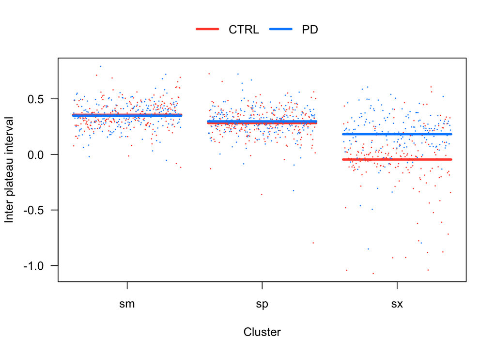

```r
visreg(m4, "cluster", by = "group", overlay = T, points = list(cex = 0.1), ylab = "Inter plateau interval", xlab = "Cluster")
```

### 3.1.1 Exploratory analysis

Duration.

```r
df.nospr$duration.tt <- df.nospr$duration.tt - mean(df.nospr$duration.tt) #center variable
summary(m5 <- lmer(time.lag.norm ~ cluster*group + duration.tt + (1+cluster|subj), data=df.nospr, control=lmerControl(optimizer="Nelder_Mead")))
```

```
## Linear mixed model fit by REML. t-tests use Satterthwaite's method [
## lmerModLmerTest]
## Formula: time.lag.norm ~ cluster * group + duration.tt + (1 + cluster |
##     subj)
##    Data: df.nospr
## Control: lmerControl(optimizer = "Nelder_Mead")
##
## REML criterion at convergence: -481.3
##
## Scaled residuals:
##     Min      1Q  Median      3Q     Max
## -5.9460 -0.4029  0.0387  0.4751  3.7183
##
## Random effects:
##  Groups   Name        Variance Std.Dev. Corr
##  subj     (Intercept) 0.001144 0.03383
##           clustersp   0.002277 0.04772   0.42
##           clustersx   0.124418 0.35273  -0.25  0.15
##  Residual             0.031874 0.17853
## Number of obs: 1185, groups:  subj, 47
##
## Fixed effects:
##                     Estimate Std. Error         df t value Pr(>|t|)
## (Intercept)        3.677e-01  1.416e-02  4.015e+01  25.973  < 2e-16 ***
## clustersp         -7.925e-02  1.963e-02  4.255e+01  -4.036 0.000222 ***
## clustersx         -4.091e-01  7.439e-02  4.221e+01  -5.500 2.05e-06 ***
## groupPD           -2.508e-02  2.078e-02  4.309e+01  -1.207 0.234019
## duration.tt       -1.564e-04  3.608e-05  1.928e+02  -4.336 2.34e-05 ***
## clustersp:groupPD  2.691e-02  2.845e-02  4.401e+01   0.946 0.349376
## clustersx:groupPD  2.401e-01  1.103e-01  4.259e+01   2.177 0.035105 *
## ---
## Signif. codes:  0 '***' 0.001 '**' 0.01 '*' 0.05 '.' 0.1 ' ' 1
##
## Correlation of Fixed Effects:
##             (Intr) clstrsp clstrsx gropPD drtn.t clstrsp:PD
## clustersp   -0.431
## clustersx   -0.259  0.172
## groupPD     -0.693  0.298   0.178
## duration.tt -0.186  0.065   0.022   0.192
## clstrsp:gPD  0.295 -0.689  -0.118  -0.441 -0.033
## clstrsx:gPD  0.173 -0.115  -0.674  -0.251 -0.008  0.170
```

```r
anova(m4, m5)
```

```
## refitting model(s) with ML (instead of REML)
```

|  | npar | AIC | BIC | logLik | deviance | Chisq | Df | Pr(>Chisq) |
| --- | --- | --- | --- | --- | --- | --- | --- | --- |
| m4 | 13 | -488.4190 | -422.4115 | 257.2095 | -514.4190 | NA | NA | NA |
| m5 | 14 | -504.4324 | -433.3475 | 266.2162 | -532.4324 | 18.01342 | 1 | 2.193528e-05 |

Sign.improvement.

Gender

```r
summary(m6 <- lmer(time.lag.norm ~ cluster*group + gender + duration.tt  + (1+cluster|subj), data=df.nospr, control=lmerControl(optimizer="Nelder_Mead")))
```

```
## Linear mixed model fit by REML. t-tests use Satterthwaite's method [
## lmerModLmerTest]
## Formula: time.lag.norm ~ cluster * group + gender + duration.tt + (1 +
##     cluster | subj)
##    Data: df.nospr
## Control: lmerControl(optimizer = "Nelder_Mead")
##
## REML criterion at convergence: -476.6
##
## Scaled residuals:
##     Min      1Q  Median      3Q     Max
## -5.9410 -0.4026  0.0396  0.4808  3.7249
##
## Random effects:
##  Groups   Name        Variance Std.Dev. Corr
##  subj     (Intercept) 0.001206 0.03472
##           clustersp   0.002343 0.04840   0.35
##           clustersx   0.124517 0.35287  -0.32  0.15
##  Residual             0.031882 0.17856
## Number of obs: 1185, groups:  subj, 47
##
## Fixed effects:
##                     Estimate Std. Error         df t value Pr(>|t|)
## (Intercept)        3.609e-01  1.536e-02  4.108e+01  23.504  < 2e-16 ***
## clustersp         -7.927e-02  1.971e-02  4.242e+01  -4.022 0.000233 ***
## clustersx         -4.091e-01  7.442e-02  4.220e+01  -5.497 2.07e-06 ***
## groupPD           -2.393e-02  2.092e-02  4.160e+01  -1.144 0.259336
## genderF            2.396e-02  2.085e-02  4.287e+01   1.149 0.256956
## duration.tt       -1.660e-04  3.716e-05  2.103e+02  -4.468 1.29e-05 ***
## clustersp:groupPD  2.684e-02  2.855e-02  4.386e+01   0.940 0.352446
## clustersx:groupPD  2.396e-01  1.103e-01  4.263e+01   2.172 0.035459 *
## ---
## Signif. codes:  0 '***' 0.001 '**' 0.01 '*' 0.05 '.' 0.1 ' ' 1
##
## Correlation of Fixed Effects:
##             (Intr) clstrsp clstrsx gropPD gendrF drtn.t clstrsp:PD
## clustersp   -0.408
## clustersx   -0.275  0.174
## groupPD     -0.656  0.305   0.204
## genderF     -0.373 -0.005  -0.002   0.036
## duration.tt -0.071  0.064   0.022   0.175 -0.254
## clstrsp:gPD  0.280 -0.689  -0.120  -0.451  0.002 -0.032
## clstrsx:gPD  0.183 -0.117  -0.675  -0.289  0.006 -0.010  0.173
```

```r
anova(m5, m6)
```

```
## refitting model(s) with ML (instead of REML)
```

|  | npar | AIC | BIC | logLik | deviance | Chisq | Df | Pr(>Chisq) |
| --- | --- | --- | --- | --- | --- | --- | --- | --- |
| m5 | 14 | -504.4324 | -433.3475 | 266.2162 | -532.4324 | NA | NA | NA |
| m6 | 15 | -503.7583 | -427.5959 | 266.8792 | -533.7583 | 1.325894 | 1 | 0.2495371 |

No improvement.

Add recording.no

```r
summary(m7 <- lmer(time.lag.norm ~ cluster*group + recording.no + duration.tt + (1+cluster|subj), data=df.nospr, control=lmerControl(optimizer="Nelder_Mead")))
```

```
## Linear mixed model fit by REML. t-tests use Satterthwaite's method [
## lmerModLmerTest]
## Formula: time.lag.norm ~ cluster * group + recording.no + duration.tt +
##     (1 + cluster | subj)
##    Data: df.nospr
## Control: lmerControl(optimizer = "Nelder_Mead")
##
## REML criterion at convergence: -466.7
##
## Scaled residuals:
##     Min      1Q  Median      3Q     Max
## -5.9367 -0.3999  0.0262  0.4743  3.7461
##
## Random effects:
##  Groups   Name        Variance Std.Dev. Corr
##  subj     (Intercept) 0.001158 0.03403
##           clustersp   0.002265 0.04759   0.42
##           clustersx   0.124471 0.35281  -0.25  0.15
##  Residual             0.031892 0.17858
## Number of obs: 1185, groups:  subj, 47
##
## Fixed effects:
##                     Estimate Std. Error         df t value Pr(>|t|)
## (Intercept)        3.624e-01  1.741e-02  8.429e+01  20.821  < 2e-16 ***
## clustersp         -7.909e-02  1.963e-02  4.256e+01  -4.029 0.000227 ***
## clustersx         -4.091e-01  7.441e-02  4.220e+01  -5.498 2.06e-06 ***
## groupPD           -2.447e-02  2.084e-02  4.301e+01  -1.174 0.246782
## recording.no       1.233e-04  2.352e-04  1.101e+03   0.524 0.600085
## duration.tt       -1.516e-04  3.722e-05  1.720e+02  -4.073 7.07e-05 ***
## clustersp:groupPD  2.664e-02  2.844e-02  4.402e+01   0.937 0.354041
## clustersx:groupPD  2.401e-01  1.103e-01  4.259e+01   2.176 0.035114 *
## ---
## Signif. codes:  0 '***' 0.001 '**' 0.01 '*' 0.05 '.' 0.1 ' ' 1
##
## Correlation of Fixed Effects:
##             (Intr) clstrsp clstrsx gropPD rcrdn. drtn.t clstrsp:PD
## clustersp   -0.360
## clustersx   -0.213  0.172
## groupPD     -0.595  0.297   0.179
## recording.n -0.580  0.017   0.000   0.054
## duration.tt -0.288  0.067   0.022   0.199  0.242
## clstrsp:gPD  0.250 -0.689  -0.119  -0.440 -0.018 -0.036
## clstrsx:gPD  0.141 -0.116  -0.674  -0.253  0.002 -0.007  0.171
```

No improvement.

Add age.

```r
summary(m8 <- lmer(time.lag.norm ~ cluster*group + duration.tt + age + (1+cluster|subj), data=df.nospr, control=lmerControl(optimizer="Nelder_Mead")))
```

```
## Linear mixed model fit by REML. t-tests use Satterthwaite's method [
## lmerModLmerTest]
## Formula:
## time.lag.norm ~ cluster * group + duration.tt + age + (1 + cluster |
##     subj)
##    Data: df.nospr
## Control: lmerControl(optimizer = "Nelder_Mead")
##
## REML criterion at convergence: -470.3
##
## Scaled residuals:
##     Min      1Q  Median      3Q     Max
## -5.9518 -0.3989  0.0364  0.4684  3.7174
##
## Random effects:
##  Groups   Name        Variance Std.Dev. Corr
##  subj     (Intercept) 0.001257 0.03546
##           clustersp   0.002270 0.04765   0.37
##           clustersx   0.124522 0.35288  -0.26  0.15
##  Residual             0.031874 0.17853
## Number of obs: 1185, groups:  subj, 47
##
## Fixed effects:
##                     Estimate Std. Error         df t value Pr(>|t|)
## (Intercept)        3.153e-01  9.531e-02  4.068e+01   3.308 0.001974 **
## clustersp         -7.914e-02  1.963e-02  4.257e+01  -4.031 0.000225 ***
## clustersx         -4.090e-01  7.442e-02  4.220e+01  -5.495 2.08e-06 ***
## groupPD           -2.565e-02  2.105e-02  4.204e+01  -1.218 0.229901
## duration.tt       -1.530e-04  3.663e-05  2.053e+02  -4.175 4.39e-05 ***
## age                7.682e-04  1.381e-03  3.995e+01   0.556 0.581237
## clustersp:groupPD  2.670e-02  2.844e-02  4.402e+01   0.939 0.353032
## clustersx:groupPD  2.394e-01  1.103e-01  4.259e+01   2.170 0.035664 *
## ---
## Signif. codes:  0 '***' 0.001 '**' 0.01 '*' 0.05 '.' 0.1 ' ' 1
##
## Correlation of Fixed Effects:
##             (Intr) clstrsp clstrsx gropPD drtn.t age    clstrsp:PD
## clustersp   -0.075
## clustersx   -0.043  0.173
## groupPD     -0.050  0.299   0.184
## duration.tt -0.175  0.066   0.023   0.180
## age         -0.989  0.010   0.003  -0.055  0.149
## clstrsp:gPD  0.056 -0.689  -0.119  -0.442 -0.034 -0.012
## clstrsx:gPD  0.034 -0.116  -0.674  -0.260 -0.009 -0.007  0.172
```

No improvement.

Add dialect.

```r
summary(m9 <- lmer(time.lag.norm ~ cluster*group + duration.tt + dialect + (1+cluster|subj), data=df.nospr, control=lmerControl(optimizer="Nelder_Mead")))
```

```
## Linear mixed model fit by REML. t-tests use Satterthwaite's method [
## lmerModLmerTest]
## Formula: time.lag.norm ~ cluster * group + duration.tt + dialect + (1 +
##     cluster | subj)
##    Data: df.nospr
## Control: lmerControl(optimizer = "Nelder_Mead")
##
## REML criterion at convergence: -470.9
##
## Scaled residuals:
##     Min      1Q  Median      3Q     Max
## -5.9430 -0.4021  0.0371  0.4712  3.7183
##
## Random effects:
##  Groups   Name        Variance Std.Dev. Corr
##  subj     (Intercept) 0.001206 0.03472
##           clustersp   0.002247 0.04740   0.45
##           clustersx   0.124529 0.35289  -0.20  0.15
##  Residual             0.031874 0.17853
## Number of obs: 1185, groups:  subj, 47
##
## Fixed effects:
##                        Estimate Std. Error         df t value Pr(>|t|)
## (Intercept)           3.733e-01  1.624e-02  4.289e+01  22.987  < 2e-16 ***
## clustersp            -7.938e-02  1.960e-02  4.253e+01  -4.049 0.000213 ***
## clustersx            -4.092e-01  7.442e-02  4.219e+01  -5.499 2.06e-06 ***
## groupPD              -2.567e-02  2.093e-02  4.202e+01  -1.226 0.226852
## duration.tt          -1.576e-04  3.679e-05  1.999e+02  -4.283 2.86e-05 ***
## dialectFrisian       -2.369e-02  3.364e-02  4.218e+01  -0.704 0.485197
## dialectNedersaksisch -1.071e-02  2.017e-02  4.205e+01  -0.531 0.598341
## clustersp:groupPD     2.715e-02  2.840e-02  4.399e+01   0.956 0.344318
## clustersx:groupPD     2.413e-01  1.104e-01  4.254e+01   2.186 0.034339 *
## ---
## Signif. codes:  0 '***' 0.001 '**' 0.01 '*' 0.05 '.' 0.1 ' ' 1
##
## Correlation of Fixed Effects:
##             (Intr) clstrsp clstrsx gropPD drtn.t dlctFr dlctNd clstrsp:PD
## clustersp   -0.370
## clustersx   -0.206  0.172
## groupPD     -0.625  0.290   0.162
## duration.tt -0.206  0.065   0.022   0.194
## dialectFrsn -0.250  0.004   0.001   0.008 -0.058
## dlctNdrskss -0.450  0.002  -0.002   0.037  0.128  0.195
## clstrsp:gPD  0.256 -0.689  -0.118  -0.430 -0.033 -0.008 -0.005
## clstrsx:gPD  0.139 -0.115  -0.674  -0.229 -0.007 -0.008  0.002  0.170
```

No improvement.

#### 3.1.1.1 Visualize final model:

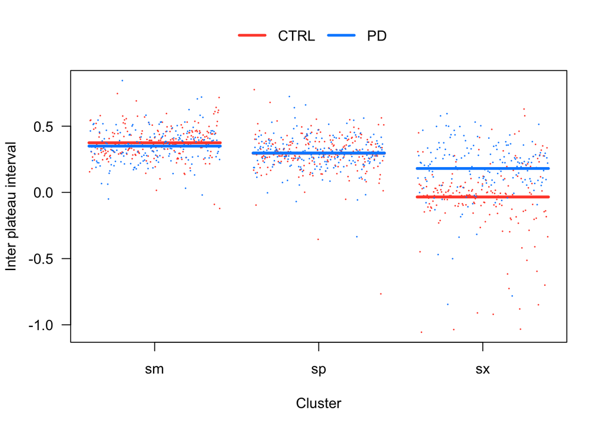

```r
visreg(m5, "cluster", by = "group", overlay = T, points = list(cex = 0.1), ylab = "Inter plateau interval", xlab = "Cluster")
```

#### 3.1.1.2 Pairwise comparisons

```r
emmeans(m5, specs = pairwise ~ group|cluster)
```

```
## $emmeans
## cluster = sm:
##  group  emmean     SE   df lower.CL upper.CL
##  CTRL   0.3677 0.0142 41.4   0.3390    0.396
##  PD     0.3426 0.0150 45.5   0.3124    0.373
##
## cluster = sp:
##  group  emmean     SE   df lower.CL upper.CL
##  CTRL   0.2884 0.0186 44.1   0.2509    0.326
##  PD     0.2903 0.0192 45.0   0.2516    0.329
##
## cluster = sx:
##  group  emmean     SE   df lower.CL upper.CL
##  CTRL  -0.0414 0.0720 41.8  -0.1868    0.104
##  PD     0.1736 0.0794 42.2   0.0133    0.334
##
## Degrees-of-freedom method: kenward-roger
## Confidence level used: 0.95
##
## $contrasts
## cluster = sm:
##  contrast  estimate     SE   df t.ratio p.value
##  CTRL - PD  0.02508 0.0209 44.4  1.202  0.2356
##
## cluster = sp:
##  contrast  estimate     SE   df t.ratio p.value
##  CTRL - PD -0.00183 0.0269 45.1 -0.068  0.9460
##
## cluster = sx:
##  contrast  estimate     SE   df t.ratio p.value
##  CTRL - PD -0.21500 0.1073 42.1 -2.005  0.0515
##
## Degrees-of-freedom method: kenward-roger
```

### 3.1.2 Checking assumptions

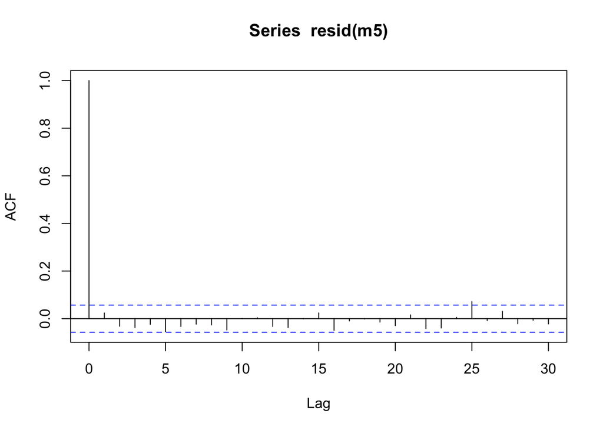

```r
acf(resid(m5))  # no autocorrelation
```

```r
vif(m5)  # Should be lower < 5 (for centered numerical variables): OK
```

```
##                   GVIF Df GVIF^(1/(2*Df))
## cluster       3.508612  2        1.368623
## group         1.348089  1        1.161072
## duration.tt   1.047656  1        1.023551
## cluster:group 4.077557  2        1.421019
```

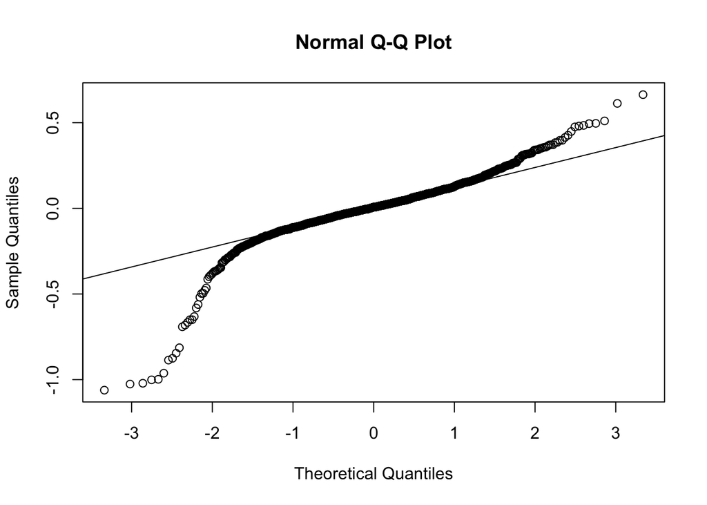

```r
qqnorm(resid(m5))
qqline(resid(m5)) #doesn't look normal
```

```r
# Trimming
df.nospr2 <- df.nospr[abs(scale(resid(m5))) < 2.5, ]  # 98.5% of original data
summary(m5.2 <- lmer(time.lag.norm ~ cluster*group + duration.tt + (1+cluster|subj), data=df.nospr2, control=lmerControl(optimizer="Nelder_Mead")))
```

```
## Linear mixed model fit by REML. t-tests use Satterthwaite's method [
## lmerModLmerTest]
## Formula: time.lag.norm ~ cluster * group + duration.tt + (1 + cluster |
##     subj)
##    Data: df.nospr2
## Control: lmerControl(optimizer = "Nelder_Mead")
##
## REML criterion at convergence: -1197
##
## Scaled residuals:
##     Min      1Q  Median      3Q     Max
## -4.0152 -0.5533 -0.0092  0.5386  3.2188
##
## Random effects:
##  Groups   Name        Variance Std.Dev. Corr
##  subj     (Intercept) 0.003785 0.06152
##           clustersp   0.006368 0.07980  -0.51
##           clustersx   0.135590 0.36823  -0.37  0.14
##  Residual             0.015536 0.12464
## Number of obs: 1153, groups:  subj, 47
##
## Fixed effects:
##                     Estimate Std. Error         df t value Pr(>|t|)
## (Intercept)        3.712e-01  1.540e-02  4.243e+01  24.106  < 2e-16 ***
## clustersp         -7.669e-02  2.033e-02  4.165e+01  -3.773 0.000504 ***
## clustersx         -3.691e-01  7.643e-02  4.197e+01  -4.829 1.85e-05 ***
## groupPD           -3.160e-02  2.238e-02  4.370e+01  -1.412 0.165073
## duration.tt       -1.556e-04  2.905e-05  3.595e+02  -5.356 1.52e-07 ***
## clustersp:groupPD  2.943e-02  2.931e-02  4.223e+01   1.004 0.321047
## clustersx:groupPD  2.277e-01  1.130e-01  4.242e+01   2.016 0.050185 .
## ---
## Signif. codes:  0 '***' 0.001 '**' 0.01 '*' 0.05 '.' 0.1 ' ' 1
##
## Correlation of Fixed Effects:
##             (Intr) clstrsp clstrsx gropPD drtn.t clstrsp:PD
## clustersp   -0.577
## clustersx   -0.363  0.161
## groupPD     -0.695  0.400   0.251
## duration.tt -0.138  0.053   0.018   0.147
## clstrsp:gPD  0.399 -0.693  -0.111  -0.581 -0.032
## clstrsx:gPD  0.245 -0.108  -0.676  -0.354 -0.009  0.159
```

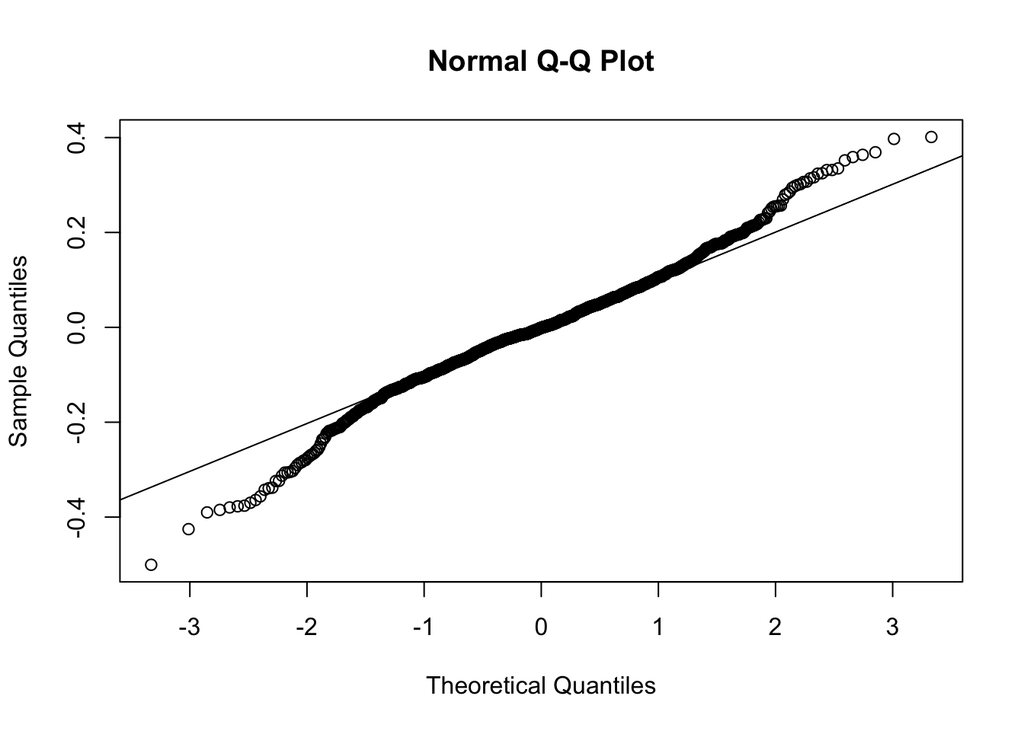

```r
qqnorm(resid(m5.2))
qqline(resid(m5.2)) #looks a lot better
```

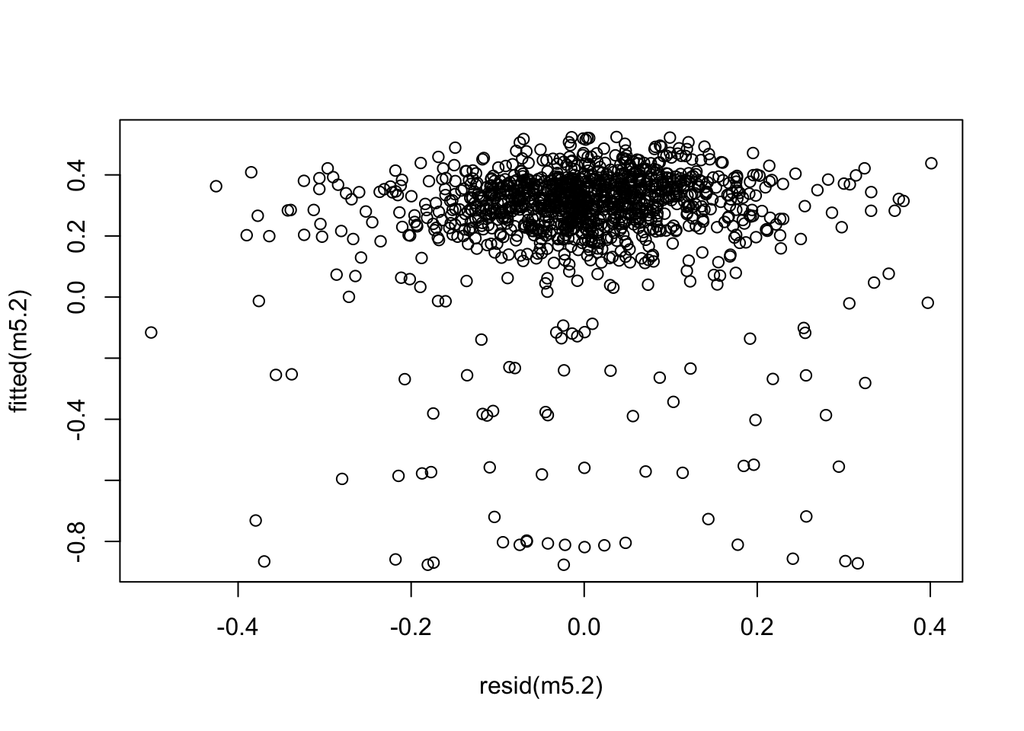

```r
plot(resid(m5.2), fitted(m5.2))
```

### 3.1.3 Check effect of tremor and akinetic on time.lag.norm for PD group only

Base model:

```r
summary(m10 <- lmer(time.lag.norm ~ cluster + duration.tt + (1+cluster|subj), data=df.nospr[df.nospr$group == "PD",], control=lmerControl(optimizer="Nelder_Mead")))
```

```
## Linear mixed model fit by REML. t-tests use Satterthwaite's method [
## lmerModLmerTest]
## Formula: time.lag.norm ~ cluster + duration.tt + (1 + cluster | subj)
##    Data: df.nospr[df.nospr$group == "PD", ]
## Control: lmerControl(optimizer = "Nelder_Mead")
##
## REML criterion at convergence: -350.5
##
## Scaled residuals:
##     Min      1Q  Median      3Q     Max
## -6.4500 -0.4798  0.0309  0.5370  3.0757
##
## Random effects:
##  Groups   Name        Variance Std.Dev. Corr
##  subj     (Intercept) 0.002402 0.04901
##           clustersp   0.002619 0.05118  -0.03
##           clustersx   0.058738 0.24236  -0.49 -0.55
##  Residual             0.025600 0.16000
## Number of obs: 559, groups:  subj, 23
##
## Fixed effects:
##               Estimate Std. Error         df t value Pr(>|t|)
## (Intercept)  3.427e-01  1.584e-02  2.023e+01  21.638 1.85e-15 ***
## clustersp   -5.240e-02  1.945e-02  2.178e+01  -2.694  0.01332 *
## clustersx   -1.731e-01  5.616e-02  2.059e+01  -3.082  0.00574 **
## duration.tt -1.462e-04  5.330e-05  1.415e+02  -2.742  0.00689 **
## ---
## Signif. codes:  0 '***' 0.001 '**' 0.01 '*' 0.05 '.' 0.1 ' ' 1
##
## Correlation of Fixed Effects:
##             (Intr) clstrsp clstrsx
## clustersp   -0.460
## clustersx   -0.449 -0.152
## duration.tt  0.125  0.028   0.016
```

```r
summary(m11 <- lmer(time.lag.norm ~ cluster + duration.tt + tremor + (1+cluster|subj), data=df.nospr[df.nospr$group == "PD",], control=lmerControl(optimizer="Nelder_Mead")))
```

```
## Linear mixed model fit by REML. t-tests use Satterthwaite's method [
## lmerModLmerTest]
## Formula: time.lag.norm ~ cluster + duration.tt + tremor + (1 + cluster |
##     subj)
##    Data: df.nospr[df.nospr$group == "PD", ]
## Control: lmerControl(optimizer = "Nelder_Mead")
##
## REML criterion at convergence: -344.4
##
## Scaled residuals:
##     Min      1Q  Median      3Q     Max
## -6.4369 -0.4755  0.0234  0.5443  3.0238
##
## Random effects:
##  Groups   Name        Variance Std.Dev. Corr
##  subj     (Intercept) 0.002345 0.04843
##           clustersp   0.002633 0.05131  -0.02
##           clustersx   0.058829 0.24255  -0.55 -0.54
##  Residual             0.025596 0.15999
## Number of obs: 559, groups:  subj, 23
##
## Fixed effects:
##               Estimate Std. Error         df t value Pr(>|t|)
## (Intercept)  3.299e-01  1.771e-02  2.475e+01  18.629 4.47e-16 ***
## clustersp   -5.215e-02  1.946e-02  2.179e+01  -2.679  0.01376 *
## clustersx   -1.752e-01  5.609e-02  2.062e+01  -3.124  0.00521 **
## duration.tt -1.484e-04  5.260e-05  1.237e+02  -2.822  0.00556 **
## tremor       8.731e-03  5.471e-03  1.661e+01   1.596  0.12933
## ---
## Signif. codes:  0 '***' 0.001 '**' 0.01 '*' 0.05 '.' 0.1 ' ' 1
##
## Correlation of Fixed Effects:
##             (Intr) clstrsp clstrsx drtn.t
## clustersp   -0.412
## clustersx   -0.421 -0.147
## duration.tt  0.112  0.028   0.016
## tremor      -0.457  0.011  -0.015  -0.002
```

No effect.

Add akinetic as a fixed effect.

```r
summary(m12 <- lmer(time.lag.norm ~ cluster + duration.tt + akinetic + (1+cluster|subj), data=df.nospr[df.nospr$group == "PD",], control=lmerControl(optimizer="Nelder_Mead")))
```

```
## Linear mixed model fit by REML. t-tests use Satterthwaite's method [
## lmerModLmerTest]
## Formula:
## time.lag.norm ~ cluster + duration.tt + akinetic + (1 + cluster |
##     subj)
##    Data: df.nospr[df.nospr$group == "PD", ]
## Control: lmerControl(optimizer = "Nelder_Mead")
##
## REML criterion at convergence: -348.7
##
## Scaled residuals:
##     Min      1Q  Median      3Q     Max
## -6.4891 -0.4782  0.0263  0.5134  3.0360
##
## Random effects:
##  Groups   Name        Variance Std.Dev. Corr
##  subj     (Intercept) 0.001247 0.03531
##           clustersp   0.002595 0.05094   0.26
##           clustersx   0.059640 0.24421  -0.62 -0.55
##  Residual             0.025570 0.15991
## Number of obs: 559, groups:  subj, 23
##
## Fixed effects:
##               Estimate Std. Error         df t value Pr(>|t|)
## (Intercept)  3.713e-01  1.759e-02  2.486e+01  21.110  < 2e-16 ***
## clustersp   -5.172e-02  1.938e-02  2.190e+01  -2.669  0.01405 *
## clustersx   -1.784e-01  5.653e-02  2.035e+01  -3.155  0.00490 **
## duration.tt -1.352e-04  5.101e-05  1.014e+02  -2.651  0.00932 **
## akinetic    -2.090e-02  7.848e-03  1.804e+01  -2.663  0.01581 *
## ---
## Signif. codes:  0 '***' 0.001 '**' 0.01 '*' 0.05 '.' 0.1 ' ' 1
##
## Correlation of Fixed Effects:
##             (Intr) clstrsp clstrsx drtn.t
## clustersp   -0.329
## clustersx   -0.393 -0.150
## duration.tt  0.151  0.027   0.013
## akinetic    -0.602 -0.016   0.022  -0.069
```

```r
anova(m11, m12)
```

```
## refitting model(s) with ML (instead of REML)
```

|  | npar | AIC | BIC | logLik | deviance | Chisq | Df | Pr(>Chisq) |
| --- | --- | --- | --- | --- | --- | --- | --- | --- |
| m11 | 12 | -364.2320 | -312.3182 | 194.1160 | -388.2320 | NA | NA | NA |
| m12 | 12 | -368.0614 | -316.1476 | 196.0307 | -392.0614 | 3.829321 | 0 | 0 |

Sign. improvement.

```r
summary(m13 <- lmer(time.lag.norm ~ cluster*akinetic + duration.tt + (1+cluster|subj), data=df.nospr[df.nospr$group == "PD",], control=lmerControl(optimizer="Nelder_Mead")))
```

```
## Linear mixed model fit by REML. t-tests use Satterthwaite's method [
## lmerModLmerTest]
## Formula:
## time.lag.norm ~ cluster * akinetic + duration.tt + (1 + cluster |
##     subj)
##    Data: df.nospr[df.nospr$group == "PD", ]
## Control: lmerControl(optimizer = "Nelder_Mead")
##
## REML criterion at convergence: -339.1
##
## Scaled residuals:
##     Min      1Q  Median      3Q     Max
## -6.4773 -0.4636  0.0181  0.5234  3.0393
##
## Random effects:
##  Groups   Name        Variance Std.Dev. Corr
##  subj     (Intercept) 0.001304 0.03611
##           clustersp   0.002597 0.05096   0.27
##           clustersx   0.062374 0.24975  -0.63 -0.57
##  Residual             0.025572 0.15991
## Number of obs: 559, groups:  subj, 23
##
## Fixed effects:
##                      Estimate Std. Error         df t value Pr(>|t|)
## (Intercept)         3.828e-01  2.049e-02  1.998e+01  18.683 4.01e-14 ***
## clustersp          -7.076e-02  2.832e-02  2.140e+01  -2.498  0.02069 *
## clustersx          -2.117e-01  8.350e-02  1.900e+01  -2.536  0.02016 *
## akinetic           -2.981e-02  1.118e-02  2.051e+01  -2.667  0.01460 *
## duration.tt        -1.425e-04  5.149e-05  9.892e+01  -2.768  0.00674 **
## clustersp:akinetic  1.417e-02  1.527e-02  2.270e+01   0.928  0.36330
## clustersx:akinetic  2.562e-02  4.574e-02  1.987e+01   0.560  0.58172
## ---
## Signif. codes:  0 '***' 0.001 '**' 0.01 '*' 0.05 '.' 0.1 ' ' 1
##
## Correlation of Fixed Effects:
##             (Intr) clstrsp clstrsx akintc drtn.t clstrsp:
## clustersp   -0.415
## clustersx   -0.489 -0.165
## akinetic    -0.724  0.320   0.352
## duration.tt  0.085  0.117  -0.004   0.015
## clstrsp:knt  0.310 -0.729   0.112  -0.455 -0.135
## clstrsx:knt  0.352  0.112  -0.724  -0.478  0.016 -0.144
```

```r
anova(m12, m13)
```

```
## refitting model(s) with ML (instead of REML)
```

|  | npar | AIC | BIC | logLik | deviance | Chisq | Df | Pr(>Chisq) |
| --- | --- | --- | --- | --- | --- | --- | --- | --- |
| m12 | 12 | -368.0614 | -316.1476 | 196.0307 | -392.0614 | NA | NA | NA |
| m13 | 14 | -365.5063 | -304.9402 | 196.7531 | -393.5063 | 1.444925 | 2 | 0.485555 |

No improvement.

### 3.1.4 Checking assumptions

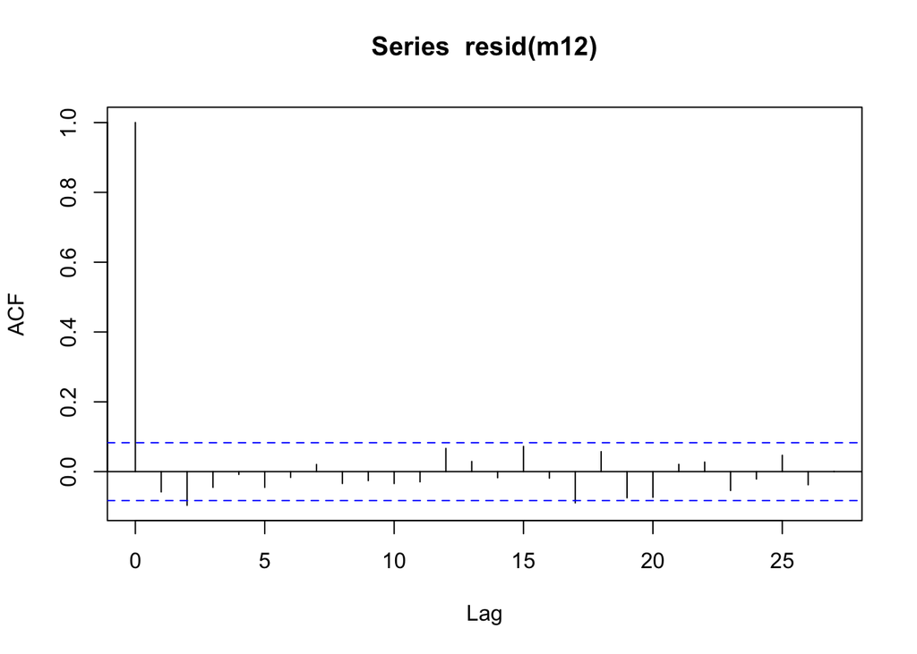

```r
acf(resid(m12))  # no autocorrelation
```

```r
vif(m12)  # Should be lower < 5 (for centered numerical variables): OK
```

```
##                 GVIF Df GVIF^(1/(2*Df))
## cluster     1.001641  2        1.000410
## duration.tt 1.005779  1        1.002886
## akinetic    1.005424  1        1.002708
```

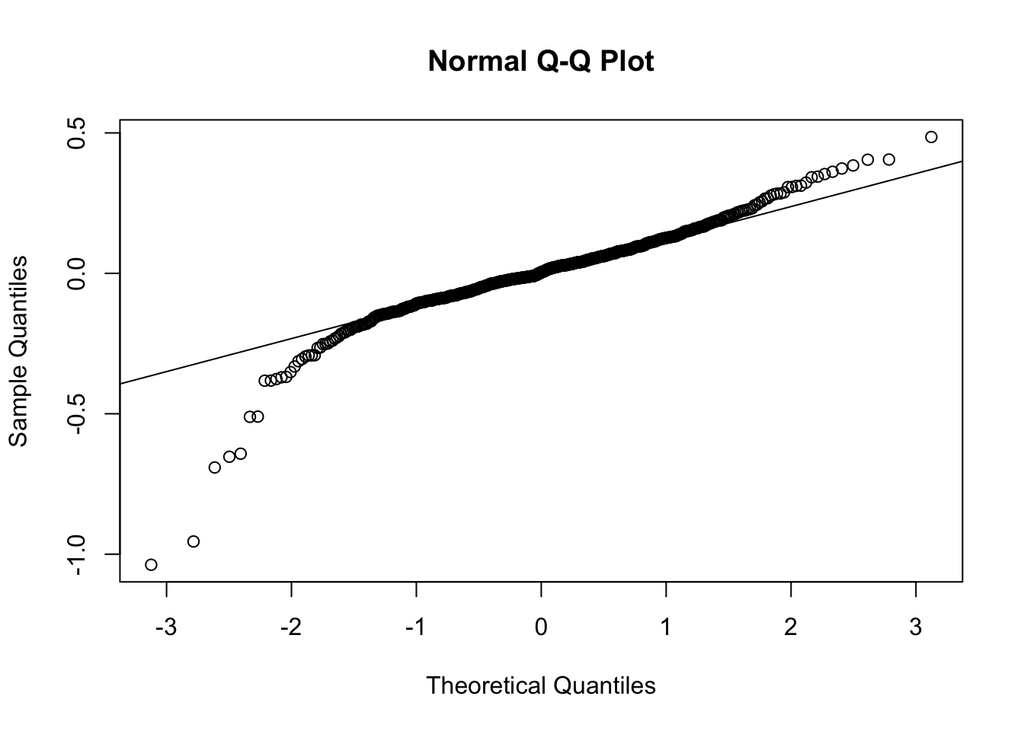

```r
qqnorm(resid(m12))
qqline(resid(m12)) # bit heavy tailed
```

```r
# Trimming
df.nospr3 <- df.nospr[abs(scale(resid(m12))) < 2.5, ]  # 98.5% of original data
summary(m12.2 <- lmer(time.lag.norm ~ cluster + duration.tt + akinetic + (1+cluster|subj), data=df.nospr3[df.nospr3$group == "PD",], control=lmerControl(optimizer="Nelder_Mead")))
```

```
## Linear mixed model fit by REML. t-tests use Satterthwaite's method [
## lmerModLmerTest]
## Formula:
## time.lag.norm ~ cluster + duration.tt + akinetic + (1 + cluster |
##     subj)
##    Data: df.nospr3[df.nospr3$group == "PD", ]
## Control: lmerControl(optimizer = "Nelder_Mead")
##
## REML criterion at convergence: -341
##
## Scaled residuals:
##     Min      1Q  Median      3Q     Max
## -6.4709 -0.4677  0.0140  0.5295  3.0080
##
## Random effects:
##  Groups   Name        Variance  Std.Dev. Corr
##  subj     (Intercept) 0.0007335 0.02708
##           clustersp   0.0019121 0.04373   0.93
##           clustersx   0.0609895 0.24696  -0.74 -0.75
##  Residual             0.0257363 0.16043
## Number of obs: 549, groups:  subj, 23
##
## Fixed effects:
##               Estimate Std. Error         df t value Pr(>|t|)
## (Intercept)  3.717e-01  1.674e-02  2.907e+01  22.206  < 2e-16 ***
## clustersp   -5.192e-02  1.865e-02  3.277e+01  -2.783  0.00887 **
## clustersx   -1.848e-01  5.711e-02  2.026e+01  -3.236  0.00409 **
## duration.tt -1.305e-04  5.055e-05  1.028e+02  -2.582  0.01123 *
## akinetic    -2.096e-02  7.628e-03  1.837e+01  -2.748  0.01308 *
## ---
## Signif. codes:  0 '***' 0.001 '**' 0.01 '*' 0.05 '.' 0.1 ' ' 1
##
## Correlation of Fixed Effects:
##             (Intr) clstrsp clstrsx drtn.t
## clustersp   -0.271
## clustersx   -0.389 -0.207
## duration.tt  0.146  0.028   0.013
## akinetic    -0.615 -0.017   0.022  -0.060
## convergence code: 0
## unable to evaluate scaled gradient
## Model failed to converge: degenerate  Hessian with 1 negative eigenvalues
```

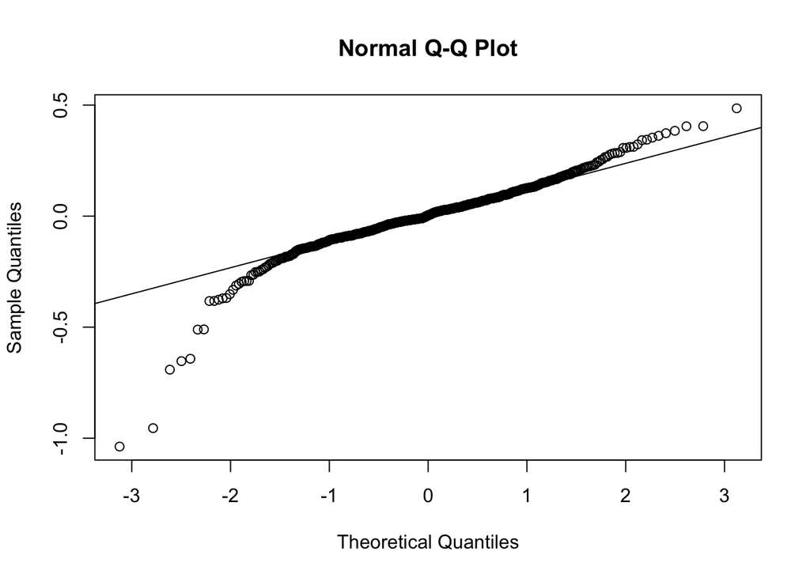

```r
qqnorm(resid(m12))
qqline(resid(m12)) # Doesn't improve
```

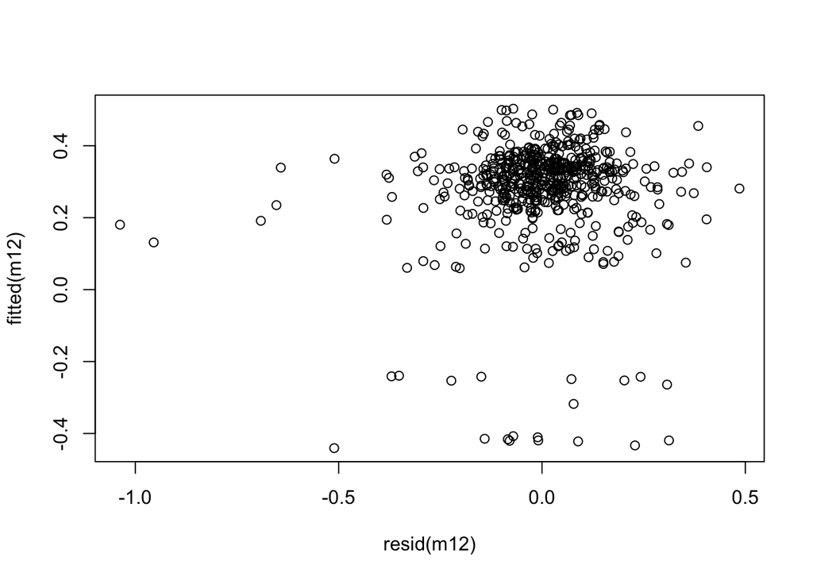

```r
plot(resid(m12), fitted(m12)) # Doesn't look OK
```